# **Data Science and Global Warming: A Closer Look at Rising Temperatures**

#### **Kyla Perkinson, Fall 2022**

[figure not shown]

## **Introduction**

#### **Motivation**

Climate change has been a concern for decades, yet within recent years there has been a dramatic politicization of the topic. Despite overwhelming evidence of it and its detrimental impacts on the planet, many continue to deny the existence of climate change or downplay its significance. I decided to do my project on increasing global temperatures and possible causes of it because I believe that the data can speak for itself. I hope to provide a clear and objective look at the reality of increasing temperatures on our planet. I believe that looking at the data is the first step to moving past the political debates surrounding the existence of climate change and will lead to more productive conversations about the policies that must be put in place to prevent this climate crisis from worsening.

This project specifically looks at how year, continent, and carbon dioxide emissions have an impact on global temperatures. I chose to look at carbon dioxide because according to the [United States Environmental Protection Agency](https://www.epa.gov/climate-indicators/climate-change-indicators-global-greenhouse-gas-emissions), carbon dioxide has significantly higher emission levels than any other greenhouse gas. At this end of this tutorial, you will be able to collect and process data, analyze data trends using an assortment of visualizations, and create predictive models using linear and polynomial regression.

#### **Required Libraries**

I will be using the following libraries throughout the project. More information about them can be found in their documentation linked below:

- [pandas](https://pandas.pydata.org/docs/)
- [numpy](https://numpy.org/doc/stable/)
- [country converter](https://pypi.org/project/country-converter/_)
- [matplotlib](https://matplotlib.org/stable/users/index.html)
- [folium](https://python-visualization.github.io/folium/)
- [statsmodels](https://www.statsmodels.org/stable/index.html)
- [sklearn](https://scikit-learn.org/stable/)

```python
import warnings
warnings.simplefilter(action="ignore", category=FutureWarning)
```

```python
import pandas as pd
import numpy as np
import country_converter as coco
import matplotlib.pyplot as plt
import folium
import statsmodels.formula.api as smf
from sklearn.preprocessing import PolynomialFeatures
from sklearn.linear_model import LinearRegression
from sklearn.model_selection import train_test_split
from sklearn.metrics import mean_squared_error
```

## **Data Collection**

The first step of this project is looking for the data I want to use. I know I want to study how the temperature has increased globally and regionally, so I want to find average temperatures for different regions in the past few decades. I found datasets for 228 different countries on the [Climate Change Knowledge Portal](https://climateknowledgeportal.worldbank.org/download-data) in which each one has the average temperature for its respective country from 1901 to 2021. I combined these datasets into one large dataset with the average temperatures from 1901 to 2021 for each country, and that can be found [here](https://github.com/kperk103/kperk103.github.io/blob/main/climate_change.csv).

```python
# Creating a dataframe from the data in the csv file
temperatures = pd.read_csv('climate_change.csv')
temperatures.head()
```

|  | Year | Temperature | Country |
| --- | --- | --- | --- |
| 0 | 1901 | 12.75 | Afghanistan |
| 1 | 1902 | 12.94 | Afghanistan |
| 2 | 1903 | 11.76 | Afghanistan |
| 3 | 1904 | 12.19 | Afghanistan |
| 4 | 1905 | 11.99 | Afghanistan |

I also know I want to look at carbon dioxide emissions from the past few decades, and I found a dataset with greenhouse gas emissions from 269 countries for the past few decades from [Our World in Data](https://github.com/owid/co2-data).

```python
# Creating a dataframe from the data in the csv file
greenhouse_gases = pd.read_csv('owid-co2-data.csv')
greenhouse_gases.head()
```

|  | country | year | iso_code | population | gdp | cement_co2 | cement_co2_per_capita | co2 | co2_growth_abs | co2_growth_prct | ... | share_global_cumulative_other_co2 | share_global_flaring_co2 | share_global_gas_co2 | share_global_luc_co2 | share_global_oil_co2 | share_global_other_co2 | total_ghg | total_ghg_excluding_lucf | trade_co2 | trade_co2_share |
| --- | --- | --- | --- | --- | --- | --- | --- | --- | --- | --- | --- | --- | --- | --- | --- | --- | --- | --- | --- | --- | --- |
| 0 | Afghanistan | 1850 | AFG | 3752993.0 | NaN | NaN | NaN | NaN | NaN | NaN | ... | NaN | NaN | NaN | 0.121 | NaN | NaN | NaN | NaN | NaN | NaN |
| 1 | Afghanistan | 1851 | AFG | 3769828.0 | NaN | NaN | NaN | NaN | NaN | NaN | ... | NaN | NaN | NaN | 0.118 | NaN | NaN | NaN | NaN | NaN | NaN |
| 2 | Afghanistan | 1852 | AFG | 3787706.0 | NaN | NaN | NaN | NaN | NaN | NaN | ... | NaN | NaN | NaN | 0.116 | NaN | NaN | NaN | NaN | NaN | NaN |
| 3 | Afghanistan | 1853 | AFG | 3806634.0 | NaN | NaN | NaN | NaN | NaN | NaN | ... | NaN | NaN | NaN | 0.115 | NaN | NaN | NaN | NaN | NaN | NaN |
| 4 | Afghanistan | 1854 | AFG | 3825655.0 | NaN | NaN | NaN | NaN | NaN | NaN | ... | NaN | NaN | NaN | 0.114 | NaN | NaN | NaN | NaN | NaN | NaN |

5 rows × 74 columns

## **Data Processing**

Now that I have created dataframes with the data I will be using, I am going to process the data so that it is easier to work with. This includes dropping columns, changing column types, renaming columns, adding country-continent mapping, and handling missing data.

#### **Data Cleaning**

To figure out what I need to do to process my data, I am going to think about what I am planning to do with it. Eventually, I want to use `folium` to create maps, and in order to do so I need the country names to match the country names `folium` uses. I can see what names are used [here](https://raw.githubusercontent.com/python-visualization/folium/master/examples/data/world-countries.json) and am going to replace my country names accordingly.

```python
# Creating lists with the current country names and the names to change them to
current_names = ["Congo (Republic of the)", "Congo (Democratic Republic of the)", "Cote d'Ivoire", "West Bank and Gaza", "Guinea-Bissau",
                 "Republic of Montenegro","Myanmar (Burma)", "Kyrgyz Republic", "Korea, Democratic People's Republic of", "Eswatini",
                 "Korea, Republic of", "United States",  "Tanzania, United Republic of", "Türkiye",  "Timor Leste", "Gambia, The",
                 "Bahamas, The",  "Federated States of Micronesia", "Virgin Islands"]
replacement_names = ["Republic of the Congo", "Democratic Republic of the Congo", "Ivory Coast", "West Bank", "Guinea Bissau", "Montenegro",
                     "Myanmar", "Kyrgyzstan", "North Korea", "Swaziland", "South Korea", "United States of America", "United Republic of Tanzania",
                     "Turkey", "East Timor", "Gambia", "The Bahamas", "Micronesia", "United States Virgin Islands"]

for i in range(len(current_names)):
    temperatures.replace(current_names[i], replacement_names[i], inplace=True)
```

I also am planning on looking at the temperature change based on continent, so I need to add a country-continent mapping to this dataset.

```python
# Using country_converter to add country-continent mapping
temperatures["Continent"] = coco.convert(names=temperatures["Country"], to="continent");
temperatures["Continent"] = temperatures["Continent"].replace("America", "Americas")
temperatures.head()
```

|  | Year | Temperature | Country | Continent |
| --- | --- | --- | --- | --- |
| 0 | 1901 | 12.75 | Afghanistan | Asia |
| 1 | 1902 | 12.94 | Afghanistan | Asia |
| 2 | 1903 | 11.76 | Afghanistan | Asia |
| 3 | 1904 | 12.19 | Afghanistan | Asia |
| 4 | 1905 | 11.99 | Afghanistan | Asia |

Now that the `temperatures` dataset has been cleaned, let's look at what the dataset contains. It contains the average temperature in celsius for each country between 1901 and 2021, and what continent each country is in.

I am now going to clean the `greenhouse_gases` dataset. I am only planning on looking at the country, year, and carbon dioxide emissions, so I am replacing the current dataset with a subset of the dataset that only contains those columns. Another method of doing this is using `pandas.DataFrame.drop()`, but since I am dropping more columns that I am keeping, I found this method to be more tedious. Next, my `temperatures` dataset only has data starting in 1901, so I am filtering the `greenhouse_gases` dataset to only contain data from the same years. Lastly, I am renaming the columns to match the names of the columns in `temperatures` for consistency.

```python
greenhouse_gases = greenhouse_gases[["country", "year", "co2"]]
greenhouse_gases = greenhouse_gases[greenhouse_gases["year"] >= 1901]
greenhouse_gases = greenhouse_gases.dropna()
greenhouse_gases = greenhouse_gases.rename(columns={"country": "Country", "year": "Year", "co2": "CO2"})
greenhouse_gases.head()
```

|  | Country | Year | CO2 |
| --- | --- | --- | --- |
| 99 | Afghanistan | 1949 | 0.015 |
| 100 | Afghanistan | 1950 | 0.084 |
| 101 | Afghanistan | 1951 | 0.092 |
| 102 | Afghanistan | 1952 | 0.092 |
| 103 | Afghanistan | 1953 | 0.106 |

Next, the dataset contains rows for regions other than just countries, such as continents. I am filtering the dataset to only contain rows with countries because otherwise it counts data twice, once in the rows with the specific countries and then again in the rows with the continent that the countries belong to.

```python
# Creating list with values to signal which rows to remove
remove_rows = ['Africa', 'Africa (GCP)', 'Antarctica', 'Asia', 'Asia (GCP)', 'Asia (excl. China and India)', 'Central America (GCP)', 'Europe',
               'Europe (GCP)','Europe (excl. EU-27)','Europe (excl. EU-28)','European Union (27)','European Union (27) (GCP)','European Union (28)',
               'French Equatorial Africa (GCP)','French West Africa (GCP)','High-income countries','Hong Kong','International transport','Kuwaiti Oil Fires (GCP)',
               'Leeward Islands (GCP)','Low-income countries','Lower-middle-income countries','Middle East (GCP)','Non-OECD (GCP)','North America',
               'North America (GCP)','North America (excl. USA)','OECD (GCP)','Oceania','Oceania (GCP)','Oman','Panama Canal Zone (GCP)',
               'Sint Maarten (Dutch part)','South America','South America (GCP)','St. Kitts-Nevis-Anguilla (GCP)','Upper-middle-income countries',
               'World', 'Ryukyu Islands (GCP)']
greenhouse_gases = greenhouse_gases[~greenhouse_gases["Country"].isin(remove_rows)]
```

Similar to before, I am renaming certain countries so that I can easily use `folium` later on in the project.

```python
# Creating lists with the current country names and the names to change them to
current_names = ["Bahamas", "Cote d'Ivoire", "Czechia", "Democratic Republic of Congo", "Eswatini", "Guinea-Bissau", "Micronesia (country)",
                 "United States", "Serbia", "Saint Helena", "Saint Kitts and Nevis", "Saint Lucia", "Saint Vincent and the Grenadines", "Virgin Islands", "Timor"]
replacement_names = ["The Bahamas", "Ivory Coast", "Czech Republic", "Democratic Republic of the Congo", "Swaziland", "Guinea Bissau",
                     "Micronesia", "United States of America", "Republic of Serbia", "St. Helena", "St. Kitts and Nevis", "St. Lucia",
                     "St. Vincent and the Grenadines", "United States Virgin Islands", "Timor-Leste"]

for i in range(len(current_names)):
    greenhouse_gases.replace(current_names[i], replacement_names[i], inplace=True)
```

I am planning on looking at carbon dioxide emissions by continent, so I am going to add country-continent mapping.

```python
# Using country_converter to add country-continent mapping
greenhouse_gases["Continent"] = coco.convert(names=greenhouse_gases["Country"], to="continent");
greenhouse_gases["Continent"] = greenhouse_gases["Continent"].replace("America", "Americas")
greenhouse_gases.head()
```

|  | Country | Year | CO2 | Continent |
| --- | --- | --- | --- | --- |
| 99 | Afghanistan | 1949 | 0.015 | Asia |
| 100 | Afghanistan | 1950 | 0.084 | Asia |
| 101 | Afghanistan | 1951 | 0.092 | Asia |
| 102 | Afghanistan | 1952 | 0.092 | Asia |
| 103 | Afghanistan | 1953 | 0.106 | Asia |

Finally, let's look at what the dataset contains now that `greenhouse_gases` has been cleaned. It contains the carbon dioxide emissions in million tonnes for each country between 1901 and 2021, and the continent each country is in.

#### **Creating color-continent mapping**

One last step I want to do before moving on to analyzing and visualizing the data is assigning colors to each continent. I am planning on having several graphs that show how the temperature and carbon dioxide emissions have changed in each continent, and assigning different colors to the continents will make it easier to understand these graphs. I am going to be using a python dictionary to assign each continent a specific color.

```python
colors = {
    'Asia' : '#93d0fc',
    'Europe' : '#356531',
    'Americas' : '#94dd9d',
    'Oceania' : '#efb8c7',
    'Africa' :  '#3a4d89'
}
```

## **Exploratory Analysis and Data Visualization**

Now it's time to analyze the data! There are four main interactions I want to look at: temperature and year, temperature and continent/country, carbon dioxide emissions and year, and temperature and carbon dioxide emissions.

#### **How has the temperature changed each year?**

To look at how global temperature has changed over time, I am going to create a new dataframe by grouping the data in `temperatures` by year and finding the average global temperature each year.

```python
# Using `groupby` to find the average global temperature
global_temps = temperatures.groupby(["Year"])['Temperature'].agg('mean')
global_temps = global_temps.reset_index()
global_temps.head()
```

|  | Year | Temperature |
| --- | --- | --- |
| 0 | 1901 | 19.083816 |
| 1 | 1902 | 18.919693 |
| 2 | 1903 | 18.978158 |
| 3 | 1904 | 18.864956 |
| 4 | 1905 | 18.947807 |

Now the new dataframe has one row per year with the global average temperature for that year.

To visualize any trends in global average temperature between the years 1901 and 2021, I am going to create a line graph.

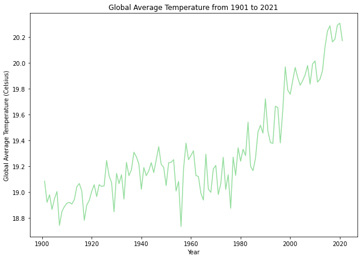

```python
# Using matplotlib to create a line plot of year vs temperature
plt.plot(global_temps["Year"], global_temps["Temperature"], c='#94dd9d')
plt.title("Global Average Temperature from 1901 to 2021")
plt.xlabel("Year")
plt.ylabel("Global Average Temperature (Celsius)")
plt.gcf().set_size_inches(10, 7)
```

In general, the global average temperature increases from 1901 to 2021. From this graph, it looks like there is a nonlinear, positive correlation between global average temperature and year. It also looks like the global average temperature starts to increase more rapidly around 1970.

#### **Does the change in temperature vary across continents and countries?**

After looking at the global average temperature from 1901 to 2021, I want to see if each continent follows a similar trend or if it varies heavily across continents.

I am going to start by making a dataframe that is grouped by continent and year to calculate the average temperature each year for each continent. I am going to do this by grouping the data by continent and year and finding the average temperature of each grouping.

```python
# Using groupby to find the average temperature of each continent for each year
continent_temp = temperatures.groupby(["Continent", "Year"])["Temperature"].agg('mean')
continent_temp = continent_temp.reset_index()
continent_temp.head()
```

|  | Continent | Year | Temperature |
| --- | --- | --- | --- |
| 0 | Africa | 1901 | 23.726207 |
| 1 | Africa | 1902 | 23.800862 |
| 2 | Africa | 1903 | 23.749310 |
| 3 | Africa | 1904 | 23.609138 |
| 4 | Africa | 1905 | 23.714655 |

Now that we have a dataset with the average temperature for each continent each year, I am going to plot this. I want to compare the continents with one another, so I am going to plot all five continents on the same graph.

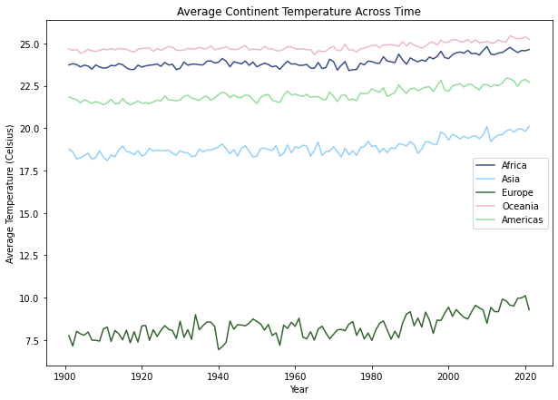

```python
# Plotting global average temperature each year for each continent
continents = ["Africa", "Asia", "Europe", "Oceania", "Americas"]

for continent in continents:
    continent_df = continent_temp[continent_temp["Continent"] == continent]
    plt.plot(continent_df["Year"], continent_df["Temperature"], c=colors[continent], label=continent)

plt.title("Average Continent Temperature Across Time")
plt.xlabel("Year")
plt.ylabel("Average Temperature (Celsius)")
plt.legend()
plt.gcf().set_size_inches(10, 7)
```

There are a few key things to note from this graph. For each continent, there appears to be a positive, linear correlation between average temperature and year. Europe seems to have the largest increase in temperature and the most fluctuations each year, while Oceania seems to have the smallest temperature increase and the fewest fluctuations each year.

##### **What does this look like on a map?**

I have looked at the temperature change globally and by continent, and now I want to break it down further by looking at the temperature change by country. First, I need to calculate how much the temperature has changed in each country between 1901 and 2021. To do that, I am going to create a new data frame, `country_temp_change`, which will have a row for each country and a column for how much the temperature has changed between 1901 and 2021. To calculate this, I am going to use the temperatures from `temperatures` for each country in 1901 and 2021 and find the difference, then add this to `country_temp_change`.

```python
# Adding all the country names to the new dataframe country_temp_change
countries = temperatures["Country"].unique()
country_temp_change = pd.DataFrame(countries, columns=["Country"])
temp_change = list()

# Calculating how much the temperature has changed between 1901 and 2021 for each country
for country in countries:
    temp_1901 = temperatures.loc[temperatures["Country"] == country, "Temperature"].iloc[0]
    temp_2021 = temperatures.loc[temperatures["Country"] == country, "Temperature"].iloc[-1]
    temp_change.append(temp_2021 - temp_1901)
country_temp_change["Temperature Change"] = temp_change
country_temp_change.head()
```

|  | Country | Temperature Change |
| --- | --- | --- |
| 0 | Afghanistan | 1.55 |
| 1 | Aruba | 0.81 |
| 2 | Angola | 0.42 |
| 3 | Anguilla | 1.12 |
| 4 | Albania | 1.55 |

Now that I have the temperature change for each country from 1901 to 2021, I can use Folium to map it! First I need to get the [GeoJSON data of the countries](https://raw.githubusercontent.com/python-visualization/folium/master/examples/data/world-countries.json), and then I can use the country names in my dataframe to map it out on a choropleth map.

```python
# Getting the GeoJSON data
url = 'https://raw.githubusercontent.com/python-visualization/folium/master/examples/data'
country_shapes = f'{url}/world-countries.json'
```

```python
# Creating the base map
map_osm = folium.Map(location=[0, 0], zoom_start=2, width=1000, height=800)

# Creating the choropleth map with the countries and temperatures to the base map
cp = folium.Choropleth(
    geo_data=country_shapes,
    name='choropleth temperatures',
    data=country_temp_change,
    columns=["Country", "Temperature Change"],
    key_on='feature.properties.name',
    fill_color='YlGn',
    nan_fill_color='white'
).add_to(map_osm)

# Adding a tooltip to show country name and adding it to the map
folium.GeoJsonTooltip(['name'], ['Country:']).add_to(cp.geojson)
folium.LayerControl().add_to(map_osm)

map_osm
```

Make this Notebook Trusted to load map: File -> Trust Notebook

[interactive chart not shown]

It looks like the temperature in South America has increased by about 0.2 to 0.7 degrees celsius, in North America is has increased by about 1 degree celsius, and in Europe and Asia is has increased the most, by about 2 degrees celsius in some countries.

Now I want to see more specific data for how temperatures change in different continents, so I am going to make a boxplot of temperature change between 1901 and 2021 for each continent. With this, I will be able to analyze the distribution of temperature change, mean, median, and any outliers for each continent.

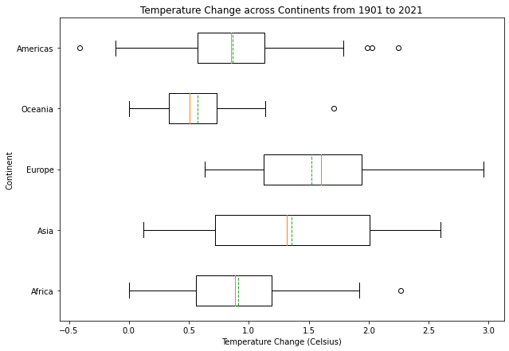

```python
# Adding country-continent mapping to country_temp_change
country_temp_change["Continent"] = coco.convert(names=country_temp_change["Country"], to="continent");
country_temp_change["Continent"] = country_temp_change["Continent"].replace("America", "Americas")
temp_change_per_continent = list()

# Creating a list of temperature changes for each continent and adding each list to temp_change_per_continent
for continent in continents:
    continent_df = country_temp_change[country_temp_change["Continent"] == continent].copy()
    continent_df = continent_df["Temperature Change"].to_numpy()
    temp_change_per_continent.append(continent_df)

plt.boxplot(temp_change_per_continent, vert=False, meanline=True, showmeans=True);
plt.yticks([1, 2, 3, 4, 5], ['Africa', 'Asia', 'Europe', 'Oceania', 'Americas'])
plt.xlabel("Temperature Change (Celsius)")
plt.ylabel("Continent")
plt.title("Temperature Change across Continents from 1901 to 2021");
plt.gcf().set_size_inches(10, 7)
```

This boxplot shows some of the same insights the map did. The green line is the average temperature change in each continent, and it shows that Europe and Asia had the highest average temperature change, which matches the analysis from the map. It also looks like there are a few outliers for the Americas, Oceania, and Africa, and I am curious to see what they are.

`matplotlib` defines outliers as points that are more than 1.5 times the interquartile range above the upper quartile and below the lower quartile, so < Q1 - 1.5 x IQR and > Q3 + 1.5 x IQR. I am going to use these bounds to find the outliers in the dataset.

```python
# Creating an outliers dataframe
outliers = pd.DataFrame()

# Find the outliers for each continent by finding the temperature changes that are < Q1 - 1.5 * IQR and > Q3 + 1.5 * IQR and adding them to the outliers dataframe
for continent in continents:
    continent_temp_change = country_temp_change[country_temp_change["Continent"] == continent].copy()
    q1, q3 = np.percentile(continent_temp_change["Temperature Change"], [25, 75])
    iqr = q3 - q1
    lower = q1 - (1.5 * iqr)
    upper = q3 + (1.5 * iqr)
    outliers = outliers.append(continent_temp_change[(continent_temp_change["Temperature Change"] < lower) | (continent_temp_change["Temperature Change"] > upper)]);

outliers.head(10)
```

|  | Country | Temperature Change | Continent |
| --- | --- | --- | --- |
| 213 | Tunisia | 2.27 | Africa |
| 150 | New Zealand | 1.71 | Oceania |
| 21 | Bolivia | -0.41 | Americas |
| 40 | Cuba | 1.99 | Americas |
| 72 | Greenland | 2.03 | Americas |
| 226 | The Bahamas | 2.25 | Americas |

The Americas have four outliers, Bolivia, Cuba, Greenland, and The Bahamas, while Africa and Oceania have one each, Tunisia and New Zealand, respectively.

#### **How have carbon dioxide emissions changed each year?**

I am now going to look at how carbon dioxide emissions have changed each year. I am first exploring how the global carbon dioxide emissions have changed between 1901 and 2021. To start, I will create a new dataframe, `global_gases`, by grouping the `greenhouse_gases` dataframe by year and finding the sum of carbon dioxide emissions across countries each year.

```python
# Using groupby to create a new dataframe that shows global carbon dioxide emissions each year
global_gases = greenhouse_gases.groupby(["Year"])["CO2"].agg('sum')
global_gases = global_gases.reset_index()
global_gases.head()
```

|  | Year | CO2 |
| --- | --- | --- |
| 0 | 1901 | 2016.745 |
| 1 | 1902 | 2067.685 |
| 2 | 1903 | 2254.091 |
| 3 | 1904 | 2279.752 |
| 4 | 1905 | 2427.311 |

Now I have a dataframe with total carbon dioxide emissions in million tonnes for each year betwen 1901 and 2021. I am going to create a graph to see how the carbon dioxide emissions have changed throughout this time period.

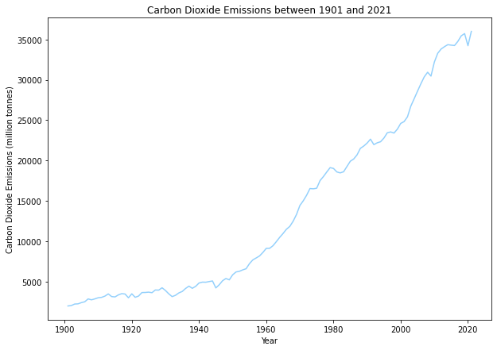

```python
# Creating a plot of global carbon dioxide emissions each year
plt.plot(global_gases["Year"], global_gases["CO2"], c='#93d0fc')
plt.xlabel("Year")
plt.ylabel("Carbon Dioxide Emissions (million tonnes)")
plt.title("Carbon Dioxide Emissions between 1901 and 2021");
plt.gcf().set_size_inches(10, 7)
```

From this graph, we can see that total carbon dioxide emissions have increased significantly between 1901 and 2021, by over 30,000 million tonnes. It looks like it is increasing at an exponential rate.

I am now interested in seeing if this trend globally is the same across countries and continents, so I am going to split the data by country and continent to do some analysis.

I am creating a new dataframe, `continent_gases`, by grouping `greenhouse_gases` by column and year and finding the sum of carbon dioxide emission for each continent each year.

```python
# Using groupby to create a new dataframe that shows each continent's carbon dioxide emissions each year
continent_gases = greenhouse_gases.groupby(["Year", "Continent"])["CO2"].agg("sum")
continent_gases = continent_gases.reset_index()
continent_gases.head()
```

|  | Year | Continent | CO2 |
| --- | --- | --- | --- |
| 0 | 1901 | Africa | 3.909 |
| 1 | 1901 | Americas | 753.086 |
| 2 | 1901 | Asia | 50.370 |
| 3 | 1901 | Europe | 1195.200 |
| 4 | 1901 | Oceania | 14.180 |

To see how carbon dioxide emissions vary across continent, I am going to plot them on the same graph.

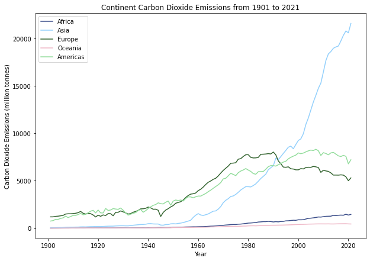

```python
# Creating a line graph to show annual carbon dioxide emissions for each continent
for continent in continents:
    continent_df = continent_gases[continent_gases["Continent"] == continent]
    plt.plot(continent_df["Year"], continent_df["CO2"], c=colors[continent], label=continent)
plt.title("Continent Carbon Dioxide Emissions from 1901 to 2021")
plt.xlabel("Year")
plt.ylabel("Carbon Dioxide Emissions (million tonnes)")
plt.legend()
plt.gcf().set_size_inches(10, 7)
```

Looking at the drastic differences in carbon dioxide emissions for each continent is making me want to look further into individual country carbon dioxide emissions. I want to see if the countries follow the same trends as their respective continents, or if there are significant outliers that are causing such drastic differences in carbon dioxide emissions by continent. To do this, I am going to make another choropleth map using `folium`.

This choropleth map is going to show the average annual increase in carbon dioxide emissions for each country. First, I am going to create a new dataframe, `country_co2_change`, which will have a row for each country and a column to show each country's annual average change in carbon dioxide emissions, measured in million tonnes per year. To get this value, I am finding the total change in carbon dioxide emissions for each country and dividing it by the number of years the country's carbon dioxide emissions are recorded.

```python
# Creating a new dataframe that has a row for each country in greenhouse_gases
countries = greenhouse_gases["Country"].unique()
country_co2_change = pd.DataFrame(countries, columns=["Country"])
co2_change = list()

# Finding the average change in carbon dioxide emissions for each country and adding it to the new dataframe
for country in countries:
    num_years = len(greenhouse_gases.loc[(greenhouse_gases["Country"] == country), "CO2"])
    co2_early = greenhouse_gases.loc[(greenhouse_gases["Country"] == country), "CO2"].iloc[0]
    co2_late = greenhouse_gases.loc[(greenhouse_gases["Country"] == country), "CO2"].iloc[-1]
    co2_change.append((co2_late - co2_early) / num_years)
country_co2_change["CO2 Change"] = co2_change
country_co2_change.head()
```

|  | Country | CO2 Change |
| --- | --- | --- |
| 0 | Afghanistan | 0.162452 |
| 1 | Albania | 0.051820 |
| 2 | Algeria | 1.662877 |
| 3 | Andorra | 0.003744 |
| 4 | Angola | 0.294111 |

Now that I have found the average carbon dioxide emissions per year for each country, I can create a map with it. Since I already imported the GeoJSON data of the countries previously, there's no need to do it again.

```python
# Creating the base map
map_osm = folium.Map(location=[0, 0], zoom_start=2, width=1000, height=800)

# Creating the choropleth map with the countries and carbon dioxide emissions to the base map
cp = folium.Choropleth(
    geo_data=country_shapes,
    name='choropleth co2',
    data=country_co2_change,
    columns=["Country", "CO2 Change"],
    key_on='feature.properties.name',
    fill_color='YlGn',
    nan_fill_color='white'
).add_to(map_osm)


# Adding a tooltip to show country name and adding it to the map
folium.GeoJsonTooltip(['name'], ['Country:']).add_to(cp.geojson)
folium.LayerControl().add_to(map_osm)

map_osm
```

Make this Notebook Trusted to load map: File -> Trust Notebook

[interactive chart not shown]

Wow! This map shows that there are quite a few countries that have notably higher changes in carbon dioxide emissions each year, specifically China, the United States, and India. To get a more in depth look of these changes in carbon dioxide emissions, I am going to create a boxplot to see the distributions of average change in carbon dioxide emissions for each continent.

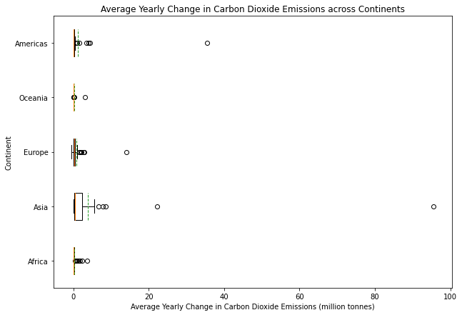

```python
# Adding country-continent mapping to country_co2_change
country_co2_change["Continent"] = coco.convert(names=country_co2_change["Country"], to="continent");
country_co2_change["Continent"] = country_co2_change["Continent"].replace("America", "Americas")
co2_change_per_continent = list()

# Creating a list of average yearly carbon dioxide emissions for each continent and adding each list to co2_change_per_continent
for continent in continents:
    continent_df = country_co2_change[country_co2_change["Continent"] == continent].copy()
    continent_df = continent_df["CO2 Change"].to_numpy()
    co2_change_per_continent.append(continent_df)

plt.boxplot(co2_change_per_continent, vert=False, meanline=True, showmeans=True);
plt.yticks([1, 2, 3, 4, 5], ['Africa', 'Asia', 'Europe', 'Oceania', 'Americas'])
plt.xlabel("Average Yearly Change in Carbon Dioxide Emissions (million tonnes)")
plt.ylabel("Continent")
plt.title("Average Yearly Change in Carbon Dioxide Emissions across Continents");
plt.gcf().set_size_inches(10, 7)
```

There are some pretty significant outliers that are making this boxplot hard to see, so I am going to first look at what those outliers are and then graph this boxplot without outliers. This way it will be easier to see the distributions, mean, and median for each continent

Using the same process as before, I am creating a new dataframe, `outliers`, and adding rows to it that have average yearly carbon dioxide emissions that are more than 1.5 times the interquartile range above the upper quartile or below the lower quartile.

```python
# Creating an outliers dataframe
outliers = pd.DataFrame()

# Finding the outliers for each continent by finding the carbon dioxide changes that are < Q1 - 1.5 * IQR and > Q3 + 1.5 * IQR and adding them to the outliers dataframe
for continent in continents:
    continent_co2_change = country_co2_change[country_co2_change["Continent"] == continent].copy()
    q1, q3 = np.percentile(continent_co2_change["CO2 Change"], [25, 75])
    iqr = q3 - q1
    lower = q1 - (1.5 * iqr)
    upper = q3 + (1.5 * iqr)
    outliers = outliers.append(continent_co2_change[(continent_co2_change["CO2 Change"] < lower) | (continent_co2_change["CO2 Change"] > upper)]);

# Sort the dataframe by 'CO2 Change' in descending orders
outliers = outliers.sort_values(by=['CO2 Change'], ascending=False)
outliers.head(5)
```

|  | Country | CO2 Change | Continent |
| --- | --- | --- | --- |
| 40 | China | 95.603067 | Asia |
| 208 | United States of America | 35.419901 | Americas |
| 89 | India | 22.285157 | Asia |
| 162 | Russia | 14.118479 | Europe |
| 97 | Japan | 8.629124 | Asia |

There are many outliers in our dataframe, and these are the five with the highest average yearly change in carbon dioxide emissions. As predicted by the map, China, the United States, and India are the top three countries with the highest average change in carbon dioxide emissions.

I am now going to create the same boxplot but without outliers so the distributions, mean, and median can be easier to see.

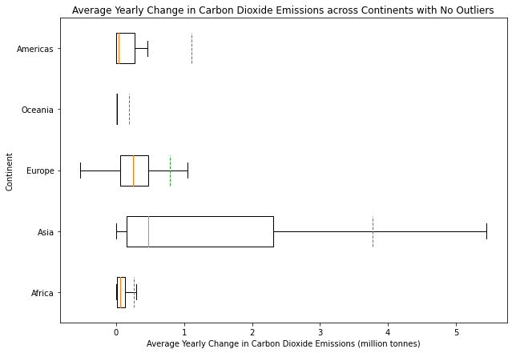

```python
co2_change_per_continent = list()

# Creating a list of average yearly carbon dioxide emissions for each continent and adding each list to co2_change_per_continent
for continent in continents:
    continent_df = country_co2_change[country_co2_change["Continent"] == continent].copy()
    continent_df = continent_df["CO2 Change"].to_numpy()
    co2_change_per_continent.append(continent_df)

plt.boxplot(co2_change_per_continent, vert=False, meanline=True, showmeans=True, showfliers=False);
plt.yticks([1, 2, 3, 4, 5], ['Africa', 'Asia', 'Europe', 'Oceania', 'Americas'])
plt.xlabel("Average Yearly Change in Carbon Dioxide Emissions (million tonnes)")
plt.ylabel("Continent")
plt.title("Average Yearly Change in Carbon Dioxide Emissions across Continents with No Outliers");
plt.gcf().set_size_inches(10, 7)
```

#### **Temperature vs Carbon Dioxide Emissions**

Now that I have had a chance to better understand how temperature and carbon dioxide emissions have changed globally and regionally, I am interested in seeing how temperatures have changed based on carbon dioxide emissions. To start, I am going to merge `global_temps` and `global_gases` to have a dataframe with the average global temperatures and average carbon dioxide emissions for each year from 1901 to 2021.

```python
# Merging global_temps and global_gases
global_temps_gases = pd.merge(global_temps, global_gases, how="inner", on=["Year"])
global_temps_gases.head()
```

|  | Year | Temperature | CO2 |
| --- | --- | --- | --- |
| 0 | 1901 | 19.083816 | 2016.745 |
| 1 | 1902 | 18.919693 | 2067.685 |
| 2 | 1903 | 18.978158 | 2254.091 |
| 3 | 1904 | 18.864956 | 2279.752 |
| 4 | 1905 | 18.947807 | 2427.311 |

To explore how temperature and carbon dioxide emissions interact with each other, I am going to use a scatter plot to look for any trends.

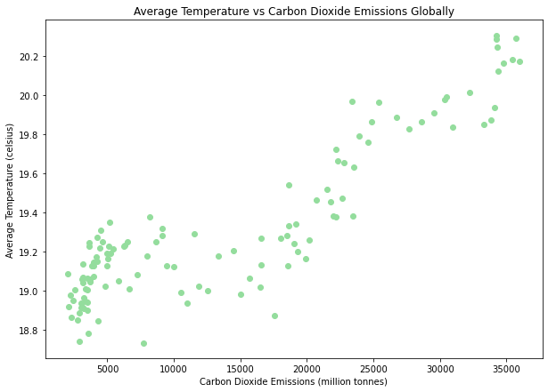

```python
# Creating a scatter plot of average temperature and carbon dioxide emissions
plt.scatter(global_temps_gases["CO2"], global_temps_gases["Temperature"], c="#94dd9d");
plt.xlabel("Carbon Dioxide Emissions (million tonnes)")
plt.ylabel("Average Temperature (celsius)")
plt.title("Average Temperature vs Carbon Dioxide Emissions Globally");
plt.gcf().set_size_inches(10, 7)
```

From this scatter plot, it looks like there is a positive correlation between carbon dioxide emissions and average temperature. Next, I am interested in how similarly the temperature and carbon dioxide emissions change each year. To do this, I am going to create a plot that has two y-axes, one for temperature and one for carbon dioxide emissions, to compare how they change over time.

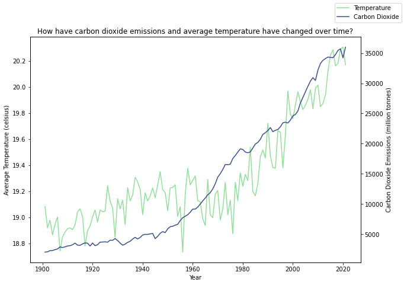

```python
# Creating a plot of average temperature each year
fig, ax = plt.subplots()
ax.plot(global_temps_gases["Year"], global_temps_gases["Temperature"], color='#94dd9d', label="Temperature")
ax.set_xlabel("Year")
ax.set_ylabel("Average Temperature (celsius)")

# Creating a second plot of carbon dioxide emissions each year on the same plot as temperature
ax2 = ax.twinx()
ax2.plot(global_temps_gases["Year"], global_temps_gases["CO2"], color='#3a4d89', label="Carbon Dioxide")
ax2.set_ylabel("Carbon Dioxide Emissions (million tonnes)")
plt.title("How have carbon dioxide emissions and average temperature have changed over time?")
fig.legend(loc='upper right')
plt.gcf().set_size_inches(10, 7)
plt.show()
```

This is interesting! It looks like carbon dioxide emissions have increased more steadily across time, while the average temperature fluctuates quite a bit between years, but both ultimately increase significantly between 1901 and 2021. It also looks like both carbon dioxide emissions and temperature start to grow at a faster rate, but the carbon dioxide emissions start to increase faster around 1950 while average temperatures start to increase faster around 1970.

## **Hypothesis Testing**

Now that some exploratory analysis has been done, I am going to use hypothesis testing to support or reject a linear relationship between temperature and year, carbon dioxide emissions, and an interaction term between year and carbon dioxide. From the exploratory analysis of year and carbon dioxide, it appears as though there is an interaction between year and carbon dioxide, which is why I have decided to add an interaction term.

#### **Is there a linear relationship?**

I am going to test the hypothesis that there is a linear relationship between temperature and year, carbon dioxide emissions, and the interaction term. Before performing this test, let's look at the regression equation we are working with and the null and alternative hypotheses.

**y = intercept + B<sub>1</sub>x<sub>1</sub> + B<sub>2</sub>x<sub>2</sub> + B<sub>3</sub>x<sub>1</sub>x<sub>2</sub>**

**Null Hypothesis:** B<sub>1</sub> = B<sub>2</sub> = B<sub>3</sub> = 0.

**Alternative Hypothesis:** B<sub>i</sub> ≠ 0.

In this equation, y = temperature, x<sub>1</sub> = year, x<sub>2</sub> = carbon dioxide emissions, and x<sub>1</sub>x<sub>2</sub> = the interaction term for year and carbon dioxide emissions.

```python
# Assigning x and y variables
X = global_temps_gases[["Year", "CO2"]]
y = global_temps_gases["Temperature"]

# Fitting the data using statsmodel and printing the summary
model = smf.ols(formula='Temperature ~ Year * CO2', data=global_temps_gases).fit()
print(model.summary())
```

```
                            OLS Regression Results
==============================================================================
Dep. Variable:            Temperature   R-squared:                       0.900
Model:                            OLS   Adj. R-squared:                  0.897
Method:                 Least Squares   F-statistic:                     349.6
Date:                Fri, 16 Dec 2022   Prob (F-statistic):           3.23e-58
Time:                        20:08:07   Log-Likelihood:                 80.160
No. Observations:                 121   AIC:                            -152.3
Df Residuals:                     117   BIC:                            -141.1
Df Model:                           3
Covariance Type:            nonrobust
==============================================================================
                 coef    std err          t      P>|t|      [0.025      0.975]
------------------------------------------------------------------------------
Intercept      4.5085      2.480      1.818      0.072      -0.403       9.420
Year           0.0077      0.001      5.903      0.000       0.005       0.010
CO2           -0.0017      0.000    -11.229      0.000      -0.002      -0.001
Year:CO2    8.609e-07   7.52e-08     11.449      0.000    7.12e-07    1.01e-06
==============================================================================
Omnibus:                        5.801   Durbin-Watson:                   1.549
Prob(Omnibus):                  0.055   Jarque-Bera (JB):                5.558
Skew:                          -0.389   Prob(JB):                       0.0621
Kurtosis:                       3.704   Cond. No.                     7.46e+09
==============================================================================

Notes:
[1] Standard Errors assume that the covariance matrix of the errors is correctly specified.
[2] The condition number is large, 7.46e+09. This might indicate that there are
strong multicollinearity or other numerical problems.
```

At significance level α = 0.05, the null hypothesis can be rejected. This is determined by looking at the value "Prob (F-statistic)" which is the probability that the null hypothesis for the full mode is true, in this case the probability that all coefficients are zero. Since the value is less than α, the null hypothesis is rejected and it suggests that there is a linear relationship between temperature and year, carbon dioxide emissions, and the interaction term.

## **Linear Regression**

The hypothesis testing supported a linear relationship between temperature and year, carbon dioxide emissions, and the interaction term. To further explore this, I want to use this last section to create a linear regression model that can predict global temperature based on these predictors.

To create the model, I am first going to split the temperatures and predictors into training and testing subsets. This is so the model can be fit using the training data and then its performance can be measured using the unseen testing data. The metric I will be using to evaluate the linear regression model is root mean square error. Three other commons metrics used to evaluate the performance of a regression model are mean square error, r square, and mean absolute error. I am choosing to use root mean square error because it is a weighted average that penalizes more for larger prediction errors, and it uses the same units as the predicted variable, which in this case is degrees celsius.

```python
# Adding a column for the interaction term
global_temps_gases["Interaction"] = global_temps_gases["Year"] * global_temps_gases["CO2"]

# Declaring the x and y variables
X = global_temps_gases[["Year", "CO2", "Interaction"]]
y = global_temps_gases["Temperature"]

# Splitting the data into training and testing data
X_train, X_test, y_train, y_test = train_test_split(X, y, test_size=0.3, random_state=42)

# Creating and fitting the model
lin_model = LinearRegression()
lin_model = lin_model.fit(X_train, y_train)

# Finding the predicted temperatures and calculating the root mean square error
y_predicted = lin_model.predict(X_test)
lin_rmse = mean_squared_error(y_test, y_predicted, squared=False)

print(f'The root mean square error of the linear regression model is {round(lin_rmse, 4)}, which means that on average, each prediction is incorrect by about {round(lin_rmse, 4)} degrees celsius.')
```

```
The root mean square error of the linear regression model is 0.1441, which means that on average, each prediction is incorrect by about 0.1441 degrees celsius.
```

To visualize how this regression compares to the actual temperatures, it can be graphed on the same plot.

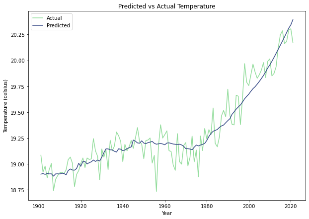

```python
# Getting temperature predictions from model to plot against actual values
predictions = lin_model.predict(X)
plt.plot(global_temps_gases["Year"], global_temps_gases["Temperature"], color="#94dd9d", label="Actual")
plt.plot(global_temps_gases["Year"], predictions, color="#3a4d89", label="Predicted")
plt.xlabel("Year")
plt.ylabel("Temperature (celsius)")
plt.title("Predicted vs Actual Temperature");
plt.legend();
plt.gcf().set_size_inches(10, 7)
```

#### **Predicting future temperatures**

Now that I have a predictive model for temperature based on year, carbon dioxide emissions, and the interaction term, I am interested in predicting the temperatures for future years. I will be using carbon dioxide emission predictions from the [Organization for Economic Co-operation and Development's Environmental Outlook to 2050](https://www.oecd.org/env/cc/49082173.pdf). According to this document, it is predicted that carbon dioxide emissions will be about 42,000 million tonnes in 2030, 47,000 million tonnes in 2040, and 55,000 million tonnes in 2050. I will be using these carbon dioxide projections with the model to determine predicted global temperatures through 2050.

To do so, I am first adding three new rows with the predicted carbon dioxide emissions for 2030, 2040, and 2050 and their interaction terms. I will then use the model to predict the temperatures based on the year and projected carbon dioxide emissions. To visualize these predicted temperatures, I am going to graph them with the actual temperatures.

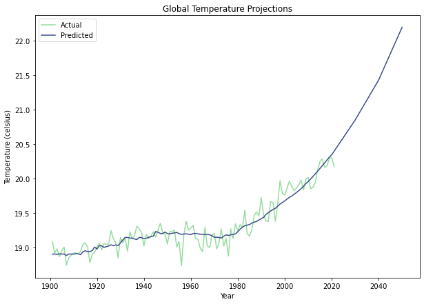

```python
# Creating a new dataframe with year and carbon dioxide emissions and adding the projected carbon dioxide emissions and interaction to it
co2_predictions = X
co2_predictions = co2_predictions.append({'Year' : 2030, 'CO2' : 42000, 'Interaction' : 2030 * 42000}, ignore_index=True)
co2_predictions = co2_predictions.append({'Year' : 2040, 'CO2' : 47000, 'Interaction' : 2040 * 47000}, ignore_index=True)
co2_predictions = co2_predictions.append({'Year' : 2050, 'CO2' : 55000, 'Interaction' : 2050 * 55000}, ignore_index=True)

# Finding the model's predictions
y_predicted = lin_model.predict(co2_predictions[["Year", "CO2", "Interaction"]])

# Plotting the current and projected temperatures
plt.plot(global_temps_gases["Year"], global_temps_gases["Temperature"], color="#94dd9d", label="Actual")
plt.plot(co2_predictions["Year"], y_predicted, color="#3a4d89", label="Predicted")
plt.xlabel("Year")
plt.ylabel("Temperature (celsius)")
plt.title("Global Temperature Projections");
plt.legend();
plt.gcf().set_size_inches(10, 7)
```

According to the model, the temperature is expected to increase by roughly 2 degrees celsius by 2050. This may seem small, but it is quite alarming. The National Center for Science Education has published [this article](https://ncse.ngo/15degc-may-not-seem-much-its-really-big-deal-heres-why) explaining why such a small increase is so significant.

## **Insight & Next Steps**

#### **What can I do to help stop global warming?**

Everyone can play a part in stopping global warming! Here is a list of changes to daily habits that everyone can do to help protect our planet:

- Eat less meat
- Turn off lights and appliances when they aren't in use
- Carpool or take public transportation
- Use reusable water bottles, plastic containers, and shopping bags
- Buy clothes second-hand and donate clothes you no longer want
- Use towels and rags instead of paper towels

Lastly, you can calculate your carbon footprint using [The Nature Conservancy's Carbon Footprint Calculator](https://www.nature.org/en-us/get-involved/how-to-help/carbon-footprint-calculator/) and get suggestions on how to decrease it.

This tutorial was just a glimpse at one of the many manmade causes of global warming. There are many other variables to look at regarding climate change, such as deforestation, other greenhouse gases, and population growth. With the information provided in this tutorial, you now have the tools needed for any further analysis that intrigues you!